# SR_02_RLTD_ORG_ADDR_L2

Related organization street address line 2 · Text report

## Overview

**Description**

Address Foreign - AddressLine2

**Table**

`SR-P02-T01-ID-RLTD-TAX-EXEMPED-ORGS` (many)

**Location code**

`SCHED-R-PART-02-COL-A`

**Family**

`SCHED-R-PART-02-COL-A` · siblings: SR_02_RLTD_ORG_ADDR_CITY, SR_02_RLTD_ORG_ADDR_CNTR, SR_02_RLTD_ORG_ADDR_L1, SR_02_RLTD_ORG_ADDR_STATE, SR_02_RLTD_ORG_ADDR_ZIP, SR_02_RLTD_ORG_EIN

**Data type**

text (xsd: StreetAddressType)

**Scope**

PC

**Status**

unreviewed

6

xpaths mapped (6 observed)

13,030

filings with a value

2009–2024

tax years observed

4

open flags (1 errors)

## Flags

| Severity | Flag | Xpath | Detail |
| --- | --- | --- | --- |
| ⚠ error | `COLLISION` | IRS990ScheduleR/IdRelatedTaxExemptOrgGrp/ForeignAddress/AddressLine2Txt | 155 filings contain 2+ of its xpaths; most common set: /Return/ReturnData/IRS990ScheduleR/IdRelatedTaxExemptOrgGrp/ForeignAddress/AddressLine2Txt ; /Return/ReturnData/IRS990ScheduleR/IdRelatedTaxExemp… |
| ⓘ info | `MANY_NOT_REPEATING` | IRS990ScheduleR/Form990ScheduleRPartII/AddressUS/AddressLine2 | many-to-one table, but 55% of values sit in no repeating element |
| ⓘ info | `MANY_NOT_REPEATING` | IRS990ScheduleR/IdRelatedTaxExemptOrgGrp/USAddress/AddressLine2 | many-to-one table, but 64% of values sit in no repeating element |
| ⓘ info | `MANY_NOT_REPEATING` | IRS990ScheduleR/IdRelatedTaxExemptOrgGrp/ForeignAddress/AddressLine2 | many-to-one table, but 53% of values sit in no repeating element |

## Xpaths

All mapped xpaths (under /Return/ReturnData or /Return/ReturnHeader), oldest first. Charts label each series by its xpath.

| Xpath | Form | Chart label | First year | Last year | Versions | Filings | Repeats in |
| --- | --- | --- | --- | --- | --- | --- | --- |
| IRS990ScheduleR/Form990ScheduleRPartII/AddressUS/AddressLine2 | Sched R | …90ScheduleR/Form990ScheduleRPartII/AddressUS/AddressLine2 | 2009 | 2012 | 15 | 1,325 | 35.8% |
| IRS990ScheduleR/Form990ScheduleRPartII/AddressForeign/AddressLine2 | Sched R | …eduleR/Form990ScheduleRPartII/AddressForeign/AddressLine2 | 2009 | 2012 | 11 | 64 | 31.2% |
| IRS990ScheduleR/IdRelatedTaxExemptOrgGrp/USAddress/AddressLine2 | Sched R | …ScheduleR/IdRelatedTaxExemptOrgGrp/USAddress/AddressLine2 | 2013 | 2013 | 3 | 464 | 27.2% |
| IRS990ScheduleR/IdRelatedTaxExemptOrgGrp/ForeignAddress/AddressLine2 | Sched R | …uleR/IdRelatedTaxExemptOrgGrp/ForeignAddress/AddressLine2 | 2013 | 2013 | 3 | 30 | 23.3% |
| IRS990ScheduleR/IdRelatedTaxExemptOrgGrp/USAddress/AddressLine2Txt | Sched R | …eduleR/IdRelatedTaxExemptOrgGrp/USAddress/AddressLine2Txt | 2014 | 2024 | 26 | 10,490 | 45.2% |
| IRS990ScheduleR/IdRelatedTaxExemptOrgGrp/ForeignAddress/AddressLine2Txt | Sched R | …R/IdRelatedTaxExemptOrgGrp/ForeignAddress/AddressLine2Txt | 2014 | 2024 | 25 | 657 | 30.7% |

## Coverage

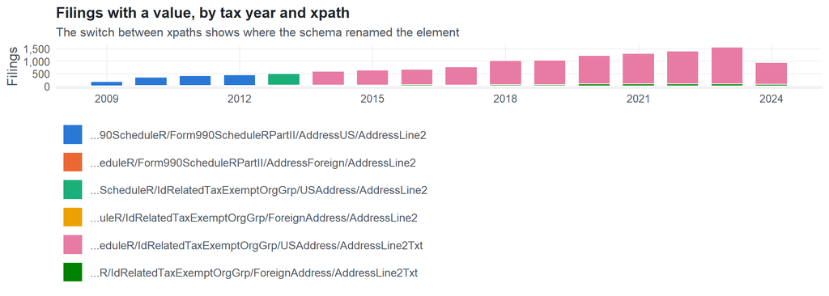

**Table view**

Table view: filings by tax year and series

| Tax year | …90ScheduleR/Form990ScheduleRPartII/AddressUS/AddressLine2 | …eduleR/Form990ScheduleRPartII/AddressForeign/AddressLine2 | …ScheduleR/IdRelatedTaxExemptOrgGrp/USAddress/AddressLine2 | …uleR/IdRelatedTaxExemptOrgGrp/ForeignAddress/AddressLine2 | …eduleR/IdRelatedTaxExemptOrgGrp/USAddress/AddressLine2Txt | …R/IdRelatedTaxExemptOrgGrp/ForeignAddress/AddressLine2Txt |
| --- | --- | --- | --- | --- | --- | --- |
| 2009 | 170 | 5 | 0 | 0 | 0 | 0 |
| 2010 | 332 | 16 | 0 | 0 | 0 | 0 |
| 2011 | 391 | 22 | 0 | 0 | 0 | 0 |
| 2012 | 432 | 21 | 0 | 0 | 0 | 0 |
| 2013 | 0 | 0 | 464 | 30 | 0 | 0 |
| 2014 | 0 | 0 | 0 | 0 | 547 | 42 |
| 2015 | 0 | 0 | 0 | 0 | 597 | 41 |
| 2016 | 0 | 0 | 0 | 0 | 626 | 49 |
| 2017 | 0 | 0 | 0 | 0 | 730 | 42 |
| 2018 | 0 | 0 | 0 | 0 | 967 | 44 |
| 2019 | 0 | 0 | 0 | 0 | 971 | 57 |
| 2020 | 0 | 0 | 0 | 0 | 1,146 | 80 |
| 2021 | 0 | 0 | 0 | 0 | 1,216 | 81 |
| 2022 | 0 | 0 | 0 | 0 | 1,330 | 77 |
| 2023 | 0 | 0 | 0 | 0 | 1,485 | 78 |
| 2024 | 0 | 0 | 0 | 0 | 875 | 66 |

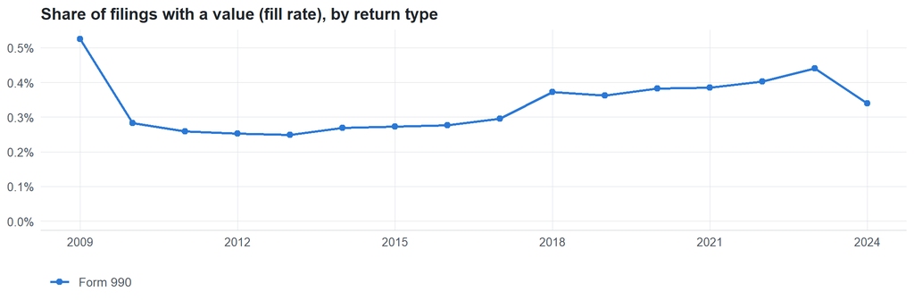

**Table view**

Table view: fill rate

| Tax year | Return type | Filings | All filings | Fill rate |
| --- | --- | --- | --- | --- |
| 2009 | Form 990 | 175 | 33,311 | 0.53% |
| 2010 | Form 990 | 348 | 123,025 | 0.28% |
| 2011 | Form 990 | 413 | 159,504 | 0.26% |
| 2012 | Form 990 | 453 | 179,688 | 0.25% |
| 2013 | Form 990 | 494 | 198,855 | 0.25% |
| 2014 | Form 990 | 589 | 218,619 | 0.27% |
| 2015 | Form 990 | 638 | 233,519 | 0.27% |
| 2016 | Form 990 | 675 | 243,903 | 0.28% |
| 2017 | Form 990 | 772 | 261,612 | 0.30% |
| 2018 | Form 990 | 1,011 | 271,442 | 0.37% |
| 2019 | Form 990 | 1,028 | 283,694 | 0.36% |
| 2020 | Form 990 | 1,226 | 320,342 | 0.38% |
| 2021 | Form 990 | 1,297 | 336,480 | 0.39% |
| 2022 | Form 990 | 1,407 | 349,055 | 0.40% |
| 2023 | Form 990 | 1,563 | 354,768 | 0.44% |
| 2024 | Form 990 | 941 | 277,298 | 0.34% |

## Repeating groups

Table cardinality in the concordance: **many**. 6 of 6 observed xpaths repeat within a filing.

Repeating element each xpath was observed in (from the raw indexed xpath)

| Xpath | Repeating element | Filings (summed over years) |
| --- | --- | --- |
| IRS990ScheduleR/Form990ScheduleRPartII/AddressForeign/AddressLine2 | (none) | 29 |
| IRS990ScheduleR/Form990ScheduleRPartII/AddressForeign/AddressLine2 | IRS990ScheduleR/Form990ScheduleRPartII | 35 |
| IRS990ScheduleR/Form990ScheduleRPartII/AddressUS/AddressLine2 | (none) | 735 |
| IRS990ScheduleR/Form990ScheduleRPartII/AddressUS/AddressLine2 | IRS990ScheduleR/Form990ScheduleRPartII | 590 |
| IRS990ScheduleR/IdRelatedTaxExemptOrgGrp/ForeignAddress/AddressLine2 | (none) | 16 |
| IRS990ScheduleR/IdRelatedTaxExemptOrgGrp/ForeignAddress/AddressLine2 | IRS990ScheduleR/IdRelatedTaxExemptOrgGrp | 14 |
| IRS990ScheduleR/IdRelatedTaxExemptOrgGrp/USAddress/AddressLine2 | (none) | 295 |
| IRS990ScheduleR/IdRelatedTaxExemptOrgGrp/USAddress/AddressLine2 | IRS990ScheduleR/IdRelatedTaxExemptOrgGrp | 169 |
| IRS990ScheduleR/IdRelatedTaxExemptOrgGrp/ForeignAddress/AddressLine2Txt | (none) | 222 |
| IRS990ScheduleR/IdRelatedTaxExemptOrgGrp/ForeignAddress/AddressLine2Txt | IRS990ScheduleR/IdRelatedTaxExemptOrgGrp | 435 |
| IRS990ScheduleR/IdRelatedTaxExemptOrgGrp/USAddress/AddressLine2Txt | (none) | 4259 |
| IRS990ScheduleR/IdRelatedTaxExemptOrgGrp/USAddress/AddressLine2Txt | IRS990ScheduleR/IdRelatedTaxExemptOrgGrp | 6231 |

## Values

| Result | Check | Detail |
| --- | --- | --- |
| ✓ pass | Values are text, not numbers | 0% of values are numeric |
| ⓘ info | No sign of truncation | …eduleR/Form990ScheduleRPartII/AddressForeign/AddressLine2: longest value is exactly 35 characters; …90ScheduleR/Form990ScheduleRPartII/AddressUS/AddressLine2: longest value is exactly 35 characters; … |
| ✓ pass | No dominant boilerplate value | most common value covers 15% of filings: “SUITE 300” |

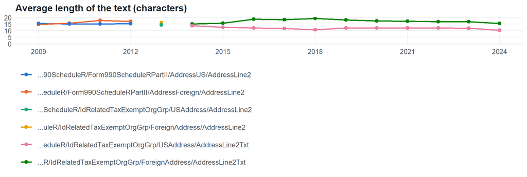

**Table view**

Table view: length and variety by tax year

| Series | Tax year | Filings | Avg length | Max length | Distinct values (approx.) |
| --- | --- | --- | --- | --- | --- |
| …90ScheduleR/Form990ScheduleRPartII/AddressUS/AddressLine2 | 2009 | 170 | 15 | 34 | 91 |
| …90ScheduleR/Form990ScheduleRPartII/AddressUS/AddressLine2 | 2010 | 332 | 15 | 35 | 170 |
| …90ScheduleR/Form990ScheduleRPartII/AddressUS/AddressLine2 | 2011 | 391 | 15 | 35 | 319 |
| …90ScheduleR/Form990ScheduleRPartII/AddressUS/AddressLine2 | 2012 | 432 | 15 | 35 | 204 |
| …eduleR/Form990ScheduleRPartII/AddressForeign/AddressLine2 | 2009 | 5 | 15 | 29 | 13 |
| …eduleR/Form990ScheduleRPartII/AddressForeign/AddressLine2 | 2010 | 16 | 16 | 33 | 26 |
| …eduleR/Form990ScheduleRPartII/AddressForeign/AddressLine2 | 2011 | 22 | 18 | 35 | 30 |
| …eduleR/Form990ScheduleRPartII/AddressForeign/AddressLine2 | 2012 | 21 | 17 | 32 | 28 |
| …ScheduleR/IdRelatedTaxExemptOrgGrp/USAddress/AddressLine2 | 2013 | 464 | 14 | 35 | 202 |
| …uleR/IdRelatedTaxExemptOrgGrp/ForeignAddress/AddressLine2 | 2013 | 30 | 16 | 32 | 32 |
| …eduleR/IdRelatedTaxExemptOrgGrp/USAddress/AddressLine2Txt | 2014 | 547 | 14 | 35 | 258 |
| …eduleR/IdRelatedTaxExemptOrgGrp/USAddress/AddressLine2Txt | 2015 | 597 | 13 | 35 | 268 |
| …eduleR/IdRelatedTaxExemptOrgGrp/USAddress/AddressLine2Txt | 2016 | 626 | 12 | 33 | 395 |
| …eduleR/IdRelatedTaxExemptOrgGrp/USAddress/AddressLine2Txt | 2017 | 730 | 12 | 33 | 341 |
| …eduleR/IdRelatedTaxExemptOrgGrp/USAddress/AddressLine2Txt | 2018 | 967 | 11 | 33 | 305 |
| …eduleR/IdRelatedTaxExemptOrgGrp/USAddress/AddressLine2Txt | 2019 | 971 | 12 | 33 | 728 |
| …eduleR/IdRelatedTaxExemptOrgGrp/USAddress/AddressLine2Txt | 2020 | 1,146 | 12 | 33 | 660 |
| …eduleR/IdRelatedTaxExemptOrgGrp/USAddress/AddressLine2Txt | 2021 | 1,216 | 12 | 33 | 678 |
| …eduleR/IdRelatedTaxExemptOrgGrp/USAddress/AddressLine2Txt | 2022 | 1,330 | 12 | 33 | 719 |
| …eduleR/IdRelatedTaxExemptOrgGrp/USAddress/AddressLine2Txt | 2023 | 1,485 | 12 | 34 | 438 |
| …eduleR/IdRelatedTaxExemptOrgGrp/USAddress/AddressLine2Txt | 2024 | 875 | 10 | 34 | 416 |
| …R/IdRelatedTaxExemptOrgGrp/ForeignAddress/AddressLine2Txt | 2014 | 42 | 15 | 34 | 35 |
| …R/IdRelatedTaxExemptOrgGrp/ForeignAddress/AddressLine2Txt | 2015 | 41 | 16 | 34 | 41 |
| …R/IdRelatedTaxExemptOrgGrp/ForeignAddress/AddressLine2Txt | 2016 | 49 | 19 | 34 | 71 |
| …R/IdRelatedTaxExemptOrgGrp/ForeignAddress/AddressLine2Txt | 2017 | 42 | 18 | 35 | 35 |
| …R/IdRelatedTaxExemptOrgGrp/ForeignAddress/AddressLine2Txt | 2018 | 44 | 19 | 35 | 35 |
| …R/IdRelatedTaxExemptOrgGrp/ForeignAddress/AddressLine2Txt | 2019 | 57 | 18 | 35 | 60 |
| …R/IdRelatedTaxExemptOrgGrp/ForeignAddress/AddressLine2Txt | 2020 | 80 | 17 | 35 | 76 |
| …R/IdRelatedTaxExemptOrgGrp/ForeignAddress/AddressLine2Txt | 2021 | 81 | 17 | 35 | 69 |
| …R/IdRelatedTaxExemptOrgGrp/ForeignAddress/AddressLine2Txt | 2022 | 77 | 17 | 35 | 78 |
| …R/IdRelatedTaxExemptOrgGrp/ForeignAddress/AddressLine2Txt | 2023 | 78 | 17 | 35 | 49 |
| …R/IdRelatedTaxExemptOrgGrp/ForeignAddress/AddressLine2Txt | 2024 | 66 | 15 | 35 | 59 |

Most common values by xpath (all years; long values truncated)

| Series | Value | Filings | Share |
| --- | --- | --- | --- |
| …90ScheduleR/Form990ScheduleRPartII/AddressUS/AddressLine2 | 1644 MILEGROUND | 45 | 3.4% |
| …90ScheduleR/Form990ScheduleRPartII/AddressUS/AddressLine2 | 501 LEON SULLIVAN WAY | 44 | 3.3% |
| …90ScheduleR/Form990ScheduleRPartII/AddressUS/AddressLine2 | 2420 ASHFORD DRIVE | 29 | 2.2% |
| …90ScheduleR/Form990ScheduleRPartII/AddressUS/AddressLine2 | SUITE 200 | 28 | 2.1% |
| …90ScheduleR/Form990ScheduleRPartII/AddressUS/AddressLine2 | 8500 LONG RAPIDS RD | 24 | 1.8% |
| …90ScheduleR/Form990ScheduleRPartII/AddressUS/AddressLine2 | Suite O | 20 | 1.5% |
| …90ScheduleR/Form990ScheduleRPartII/AddressUS/AddressLine2 | SUITE 210 | 19 | 1.4% |
| …90ScheduleR/Form990ScheduleRPartII/AddressUS/AddressLine2 | Suite 100 | 17 | 1.3% |
| …90ScheduleR/Form990ScheduleRPartII/AddressUS/AddressLine2 | 100 MICHIGAN AVE NE | 16 | 1.2% |
| …90ScheduleR/Form990ScheduleRPartII/AddressUS/AddressLine2 | 1231 EAST BELTLINE NE | 16 | 1.2% |
| …90ScheduleR/Form990ScheduleRPartII/AddressUS/AddressLine2 | 1726 KNOLLCREST CIRCLE SE | 16 | 1.2% |
| …90ScheduleR/Form990ScheduleRPartII/AddressUS/AddressLine2 | 212 S SULLIVAN AVENUE | 16 | 1.2% |
| …90ScheduleR/Form990ScheduleRPartII/AddressUS/AddressLine2 | 407 S NELSON | 16 | 1.2% |
| …90ScheduleR/Form990ScheduleRPartII/AddressUS/AddressLine2 | 615 S BOWER | 16 | 1.2% |
| …90ScheduleR/Form990ScheduleRPartII/AddressUS/AddressLine2 | 750 FULLER AVE NE | 16 | 1.2% |
| …90ScheduleR/Form990ScheduleRPartII/AddressUS/AddressLine2 | PO BOX 1009 | 16 | 1.2% |
| …90ScheduleR/Form990ScheduleRPartII/AddressUS/AddressLine2 | 225 N STATE STREET | 15 | 1.1% |
| …90ScheduleR/Form990ScheduleRPartII/AddressUS/AddressLine2 | 300 N PATTERSON RD | 15 | 1.1% |
| …90ScheduleR/Form990ScheduleRPartII/AddressUS/AddressLine2 | Suite B | 12 | 0.9% |
| …90ScheduleR/Form990ScheduleRPartII/AddressUS/AddressLine2 | SUITE 300 | 11 | 0.8% |
| …90ScheduleR/Form990ScheduleRPartII/AddressUS/AddressLine2 | 8 SOUTH MICHIGAN AVE | 8 | 0.6% |
| …90ScheduleR/Form990ScheduleRPartII/AddressUS/AddressLine2 | 1520 COOPER HILL ROAD | 8 | 0.6% |
| …90ScheduleR/Form990ScheduleRPartII/AddressUS/AddressLine2 | SUITE 100 | 8 | 0.6% |
| …90ScheduleR/Form990ScheduleRPartII/AddressUS/AddressLine2 | 187 WOODLAWN AVENUE | 4 | 0.3% |
| …eduleR/Form990ScheduleRPartII/AddressForeign/AddressLine2 | Apt 2 | 3 | 4.7% |
| …eduleR/Form990ScheduleRPartII/AddressForeign/AddressLine2 | C/Calle Arturo Ulsar Pietro | 3 | 4.7% |
| …eduleR/Form990ScheduleRPartII/AddressForeign/AddressLine2 | Calle Principal Casa 352 A/B | 3 | 4.7% |
| …eduleR/Form990ScheduleRPartII/AddressForeign/AddressLine2 | 2 Woodstock Link | 3 | 4.7% |
| …eduleR/Form990ScheduleRPartII/AddressForeign/AddressLine2 | 21 TAMPINES AVENUE 1 | 3 | 4.7% |
| …eduleR/Form990ScheduleRPartII/AddressForeign/AddressLine2 | 223 Main Street | 3 | 4.7% |

First rows shown.

## Examples

| Tax year | Return | Xpath | Organization | Value | Source |
| --- | --- | --- | --- | --- | --- |
| 2024 | 990 | IRS990ScheduleR/IdRelatedTaxExemptOrgGrp/ForeignAddress/AddressLine2Txt | PARTNERS IN HEALTH A NONPROFIT CORPORATION | Suite 603 | [XML](https://gt990datalake-rawdata.s3.amazonaws.com/EfileData/XmlFiles/202640999349300744_public.xml) |
| 2024 | 990 | IRS990ScheduleR/IdRelatedTaxExemptOrgGrp/USAddress/AddressLine2Txt | Iowa Federation of Labor AFL-CIO | Suite A | [XML](https://gt990datalake-rawdata.s3.amazonaws.com/EfileData/XmlFiles/202511619349301666_public.xml) |
| 2023 | 990 | IRS990ScheduleR/IdRelatedTaxExemptOrgGrp/ForeignAddress/AddressLine2Txt | PLANNED PARENTHOOD FEDERATION OF AMERICA INC | 11TH FL | [XML](https://gt990datalake-rawdata.s3.amazonaws.com/EfileData/XmlFiles/202501259349302345_public.xml) |
| 2023 | 990 | IRS990ScheduleR/IdRelatedTaxExemptOrgGrp/USAddress/AddressLine2Txt | ASCENSION PROVIDENCE ROCHESTER FOUNDATION | PO BOX 45998 | [XML](https://gt990datalake-rawdata.s3.amazonaws.com/EfileData/XmlFiles/202511359349304421_public.xml) |
| 2022 | 990 | IRS990ScheduleR/IdRelatedTaxExemptOrgGrp/ForeignAddress/AddressLine2Txt | University of Victoria | 3800 Finnerty Road V8P 5C2 | [XML](https://gt990datalake-rawdata.s3.amazonaws.com/EfileData/XmlFiles/202410479349300101_public.xml) |
| 2022 | 990 | IRS990ScheduleR/IdRelatedTaxExemptOrgGrp/USAddress/AddressLine2Txt | CASCADE MEADOWS SENIOR APARTMENTS | 500 E 2ND ST | [XML](https://gt990datalake-rawdata.s3.amazonaws.com/EfileData/XmlFiles/202303179349310515_public.xml) |
| 2021 | 990 | IRS990ScheduleR/IdRelatedTaxExemptOrgGrp/ForeignAddress/AddressLine2Txt | TRUSTEES OF HAMILTON COLLEGE | Piso BAJ Pta 1 | [XML](https://gt990datalake-rawdata.s3.amazonaws.com/EfileData/XmlFiles/202301319349305870_public.xml) |
| 2021 | 990 | IRS990ScheduleR/IdRelatedTaxExemptOrgGrp/USAddress/AddressLine2Txt | THE HEALTHCARE ALLIANCE OF | 3200 WEST MARKET STREET 105 | [XML](https://gt990datalake-rawdata.s3.amazonaws.com/EfileData/XmlFiles/202203159349302170_public.xml) |
| 2020 | 990 | IRS990ScheduleR/IdRelatedTaxExemptOrgGrp/ForeignAddress/AddressLine2Txt | WORLD LEARNING INC | Barrio Morro Bento | [XML](https://gt990datalake-rawdata.s3.amazonaws.com/EfileData/XmlFiles/202241269349302029_public.xml) |
| 2020 | 990 | IRS990ScheduleR/IdRelatedTaxExemptOrgGrp/USAddress/AddressLine2Txt | ATLANTIC CITY SPORTS COMMISSION INC | 1 CONVENTION BLVD | [XML](https://gt990datalake-rawdata.s3.amazonaws.com/EfileData/XmlFiles/202111309349303011_public.xml) |
| 2019 | 990 | IRS990ScheduleR/IdRelatedTaxExemptOrgGrp/ForeignAddress/AddressLine2Txt | Harvard Management Private Equity Corp | Corporate Park Lower Parel | [XML](https://gt990datalake-rawdata.s3.amazonaws.com/EfileData/XmlFiles/202121339349303382_public.xml) |
| 2019 | 990 | IRS990ScheduleR/IdRelatedTaxExemptOrgGrp/USAddress/AddressLine2Txt | NATIONAL FIRE SAFETY COUNCIL INC | 4065 PAGE AVENUE | [XML](https://gt990datalake-rawdata.s3.amazonaws.com/EfileData/XmlFiles/202112109349300231_public.xml) |

## Reviewer checklist

- The definition matches the form line and instructions for every xpath’s schema years.
- Every xpath pooled here measures the same thing on the 990 and 990-EZ (close enough for analysis).
- The coverage chart has no unexplained gaps or jumps between tax years.
- Each open flag is fixed, or accepted with a note in validation_log.csv.
- Values answer the question on the form line (not another line’s explanation).
- Boilerplate such as ‘See Schedule O’ or ‘N/A’ is expected here, or should be treated as missing.
- Text that is really a number or a code is flagged for a different data type.

Record the review as a row in `inst/extdata/src/validation_log.csv` (variable_name, reviewer, date, status, note). Evidence built 2026-09-23 17:09:04 MST from the ef2 DuckDB builds (tax years 2009–2024).